# JamesCitrate

**Code for all diagnostic plots is taken from the book “An R companion to applied regression”, John Fox Sanford Weisberg**

# Loading data

```r
data <-  read.csv("~/Downloads/Citrate exudation.csv")
data$Prate <- factor(data$Prate, levels = c("1","5","50")) # Turn pyruvate into a treatment factor, not a numerical variable. It is more of a treatment level, rather then many different pyruvate concentrations.
data$WAT <- factor(data$WAT, levels = c("3","4","5","6") )
data$CO2 <- factor(data$CO2, levels = c("Ambient","Elevated") )
require(plyr)
data$WAT <- revalue(data$WAT, c("3"="WAT3", "4"="WAT4", "5"="WAT5", "6"="WAT6"))
```

## A quick look at data

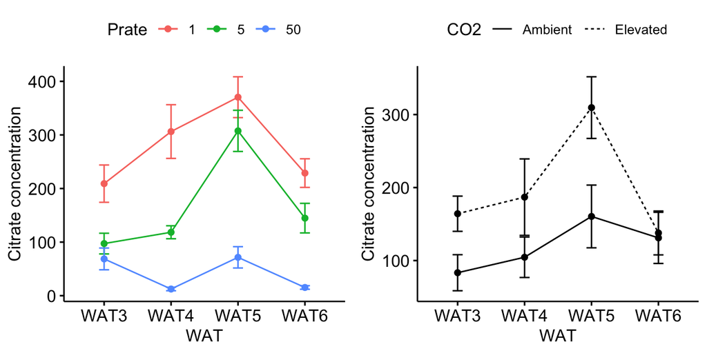

Figure 1: A quick look at data using package ggpubr.

```r
library(ggplot2)
library(ggpubr)
library(reshape2)
data.melt <- melt(data, measure.var = "Citrate")

Lineplt1 <- ggline(data = data.melt, x = "WAT", y = "value", color = "Prate", add = c("mean_se"), ylab = "Citrate concentration")

Lineplt2 <- ggline(data = data.melt, x = "WAT", y = "value", linetype  = "CO2", add = c("mean_se"), ylab = "Citrate concentration")

p <- ggarrange(Lineplt1, Lineplt2, nrow = 1, ncol =2)
p
```

It looks to me as if in WAT5 something happened to citrate in samples treated with pyruvate concentration ‘1’ and ‘5’ but mostly under elevated CO<sub>2</sub>. But was there an additional effect of pyruvate? I.e. was there an interaction? I will test that in the model.

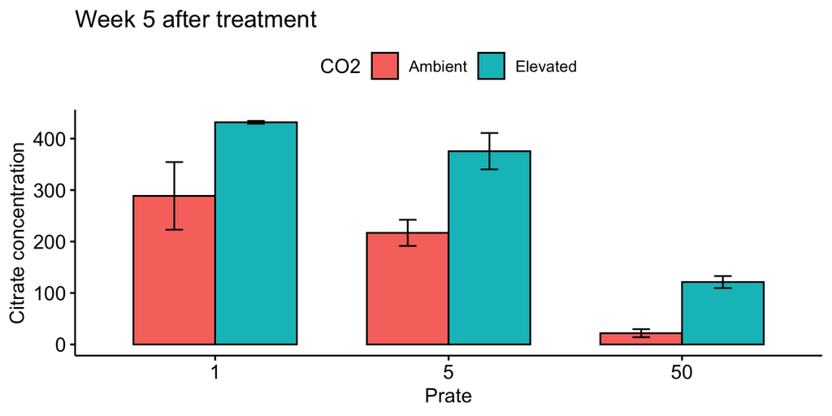

Figure 2: barplot of data from WAT5 only using package ggpubr.

```r
library(tidyverse)
dataWAT5 <- data %>% filter(WAT == "WAT5")
dataWAT5 <- melt(dataWAT5, measure.var = "Citrate")

barplot <- ggbarplot(data = dataWAT5, x = "Prate", y = "value", fill = "CO2", add = c("mean_se"), position = position_dodge(0.7) , ylab = "Citrate concentration") + ggtitle("Week 5 after treatment")
barplot
```

Looking at the means from WAT5 it seems that the difference between ambient and elevated did not change with different levels of pyruvate.

# Model and diagnostic plots

- I treated all predictors for citrate as factors - including pyruvate. This made more sense to me.
- Hence the model is a ‘Multiway Anova’
- Model info on pg 160 - 170++ of book
- Diagnostic plots on pg 31 - 36

## Using the lm function

```r
modelcitrate <-  lm(Citrate ~ CO2 * Prate, data = data)
modelcitrate
```

```
##
## Call:
## lm(formula = Citrate ~ CO2 * Prate, data = data)
##
## Coefficients:
##         (Intercept)          CO2Elevated               Prate5
##              216.15               123.54               -96.82
##             Prate50   CO2Elevated:Prate5  CO2Elevated:Prate50
##             -202.94               -40.00               -69.60
```

```r
summary(modelcitrate)
```

```
##
## Call:
## lm(formula = Citrate ~ CO2 * Prate, data = data)
##
## Residuals:
##      Min       1Q   Median       3Q      Max
## -206.289  -59.172   -1.303   40.638  260.288
##
## Coefficients:
##                     Estimate Std. Error t value Pr(>|t|)
## (Intercept)           216.15      22.03   9.811 1.24e-15 ***
## CO2Elevated           123.54      31.16   3.965 0.000152 ***
## Prate5                -96.82      31.16  -3.107 0.002566 **
## Prate50              -202.94      31.71  -6.400 8.14e-09 ***
## CO2Elevated:Prate5    -40.00      43.72  -0.915 0.362785
## CO2Elevated:Prate50   -69.60      44.11  -1.578 0.118329
## ---
## Signif. codes:  0 '***' 0.001 '**' 0.01 '*' 0.05 '.' 0.1 ' ' 1
##
## Residual standard error: 85.33 on 85 degrees of freedom
##   (5 observations deleted due to missingness)
## Multiple R-squared:  0.6236, Adjusted R-squared:  0.6015
## F-statistic: 28.17 on 5 and 85 DF,  p-value: < 2.2e-16
```

```r
## Anova type 1
anova(modelcitrate)
```

```
## Analysis of Variance Table
##
## Response: Citrate
##           Df Sum Sq Mean Sq F value    Pr(>F)
## CO2        1 151930  151930 20.8670 1.653e-05 ***
## Prate      2 855160  427580 58.7263 < 2.2e-16 ***
## CO2:Prate  2  18267    9134  1.2545    0.2905
## Residuals 85 618876    7281
## ---
## Signif. codes:  0 '***' 0.001 '**' 0.01 '*' 0.05 '.' 0.1 ' ' 1
```

```r
## Anova type 2
car::Anova(modelcitrate, type = 2)
```

```
## Anova Table (Type II tests)
##
## Response: Citrate
##           Sum Sq Df F value    Pr(>F)
## CO2       171965  1 23.6187 5.311e-06 ***
## Prate     855160  2 58.7263 < 2.2e-16 ***
## CO2:Prate  18267  2  1.2545    0.2905
## Residuals 618876 85
## ---
## Signif. codes:  0 '***' 0.001 '**' 0.01 '*' 0.05 '.' 0.1 ' ' 1
```

```r
## Anova type 3
car::Anova(modelcitrate, type = 3)
```

```
## Anova Table (Type III tests)
##
## Response: Citrate
##             Sum Sq Df F value    Pr(>F)
## (Intercept) 700830  1 96.2560 1.236e-15 ***
## CO2         114472  1 15.7223 0.0001524 ***
## Prate       298234  2 20.4806 5.499e-08 ***
## CO2:Prate    18267  2  1.2545 0.2904530
## Residuals   618876 85
## ---
## Signif. codes:  0 '***' 0.001 '**' 0.01 '*' 0.05 '.' 0.1 ' ' 1
```

Confirming there was no interaction.

## Using the aov function

This gives the exact same results as from the lm function

```r
modelcitrateaov <-  aov(Citrate ~ CO2 * Prate, data = data)
summary(modelcitrateaov)
```

```
##             Df Sum Sq Mean Sq F value   Pr(>F)
## CO2          1 151930  151930  20.867 1.65e-05 ***
## Prate        2 855160  427580  58.726  < 2e-16 ***
## CO2:Prate    2  18267    9134   1.254     0.29
## Residuals   85 618876    7281
## ---
## Signif. codes:  0 '***' 0.001 '**' 0.01 '*' 0.05 '.' 0.1 ' ' 1
## 5 observations deleted due to missingness
```

```r
## Anova type 2
car::Anova(modelcitrateaov, type = 2)
```

```
## Anova Table (Type II tests)
##
## Response: Citrate
##           Sum Sq Df F value    Pr(>F)
## CO2       171965  1 23.6187 5.311e-06 ***
## Prate     855160  2 58.7263 < 2.2e-16 ***
## CO2:Prate  18267  2  1.2545    0.2905
## Residuals 618876 85
## ---
## Signif. codes:  0 '***' 0.001 '**' 0.01 '*' 0.05 '.' 0.1 ' ' 1
```

```r
## Anova type 3
car::Anova(modelcitrateaov, type = 3)
```

```
## Anova Table (Type III tests)
##
## Response: Citrate
##             Sum Sq Df F value    Pr(>F)
## (Intercept) 700830  1 96.2560 1.236e-15 ***
## CO2         114472  1 15.7223 0.0001524 ***
## Prate       298234  2 20.4806 5.499e-08 ***
## CO2:Prate    18267  2  1.2545 0.2904530
## Residuals   618876 85
## ---
## Signif. codes:  0 '***' 0.001 '**' 0.01 '*' 0.05 '.' 0.1 ' ' 1
```

## You can also use this package to print model results directly into a neat table

```r
library(sjPlot)
tab_model(modelcitrate)
```

|  | Citrate |  |  |
| --- | --- | --- | --- |
| Predictors | Estimates | CI | p |
| (Intercept) | 216.15 | 172.35 – 259.96 | **<0.001** |
| CO2 [Elevated] | 123.54 | 61.59 – 185.49 | **<0.001** |
| Prate [5] | -96.82 | -158.77 – -34.87 | **0.003** |
| Prate [50] | -202.94 | -265.98 – -139.89 | **<0.001** |
| CO2 [Elevated] * Prate [5] | -40.00 | -126.92 – 46.92 | 0.363 |
| CO2 [Elevated] * Prate [50] | -69.60 | -157.31 – 18.11 | 0.118 |
| Observations | 91 |  |  |
| R<sup>2</sup> / R<sup>2</sup> adjusted | 0.624 / 0.601 |  |  |

## Histogram and qqplot of residuals

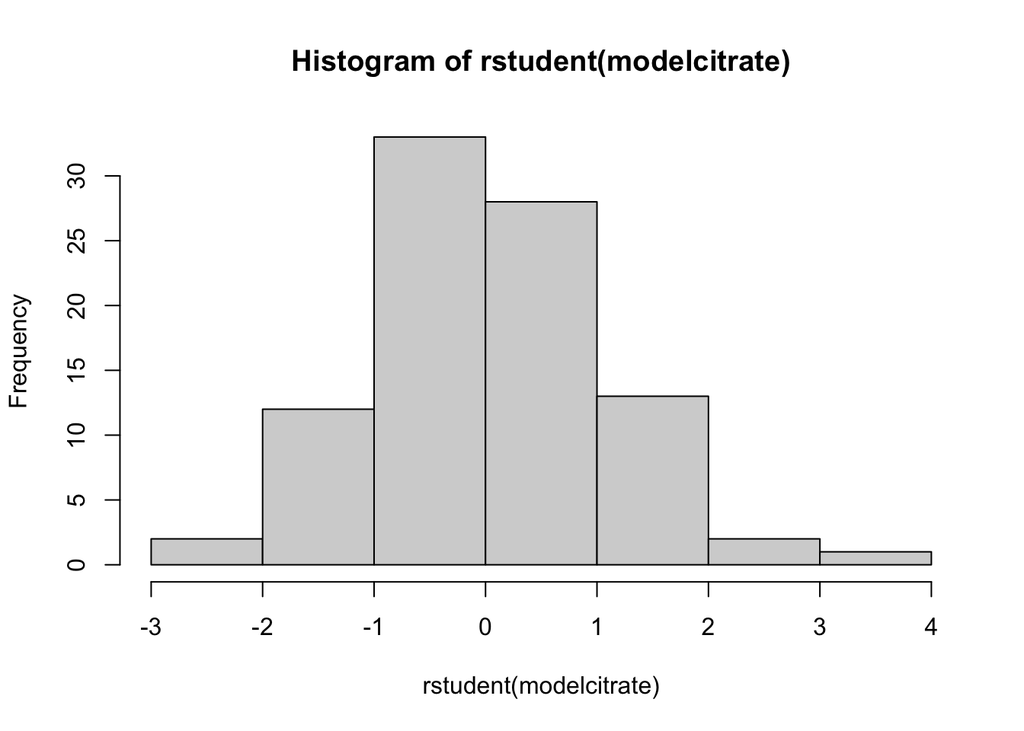

Figure 3: Histogram of studentized residuals from regression

```r
require(car)
hist(rstudent(modelcitrate)) # histogram of studentized residuals from regression
```

```r
shapiro.test(resid(modelcitrate))
```

```
##
##  Shapiro-Wilk normality test
##
## data:  resid(modelcitrate)
## W = 0.98583, p-value = 0.4315
```

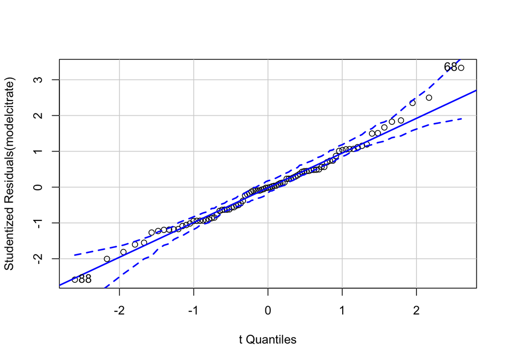

Figure 4: Quantile comparison of studentized residuals from regression. The broken lines show a bootstrapped pointwise 95% confidence envelope for the points

```
## [1] 68 88
```

```r
qqPlot(modelcitrate)
```

## Testing for influencial samples, i.e. outliers

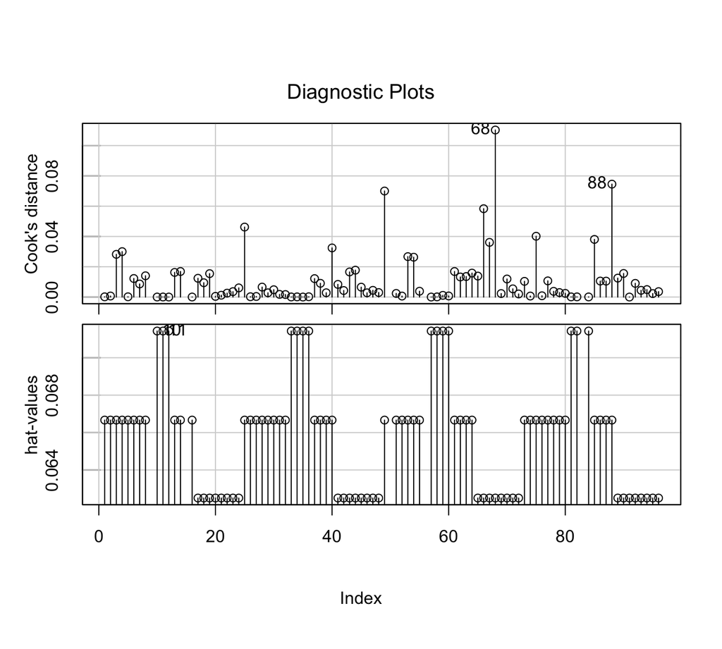

Figure 5: Index plots of Cook’s distance and hat values, from the regression

```r
influenceIndexPlot(modelcitrate , vars = c("Cook", "hat"))
```

This looks o.k to me. I learned that Cook’s distance > 1 is bad.

## Checking for independance of residuals

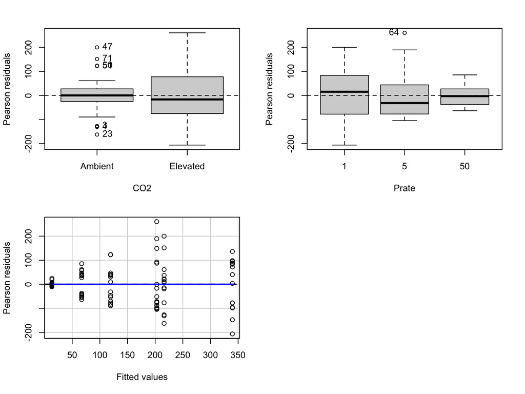

Figure 6: Residual plot

```r
residualPlots(modelcitrate)
```

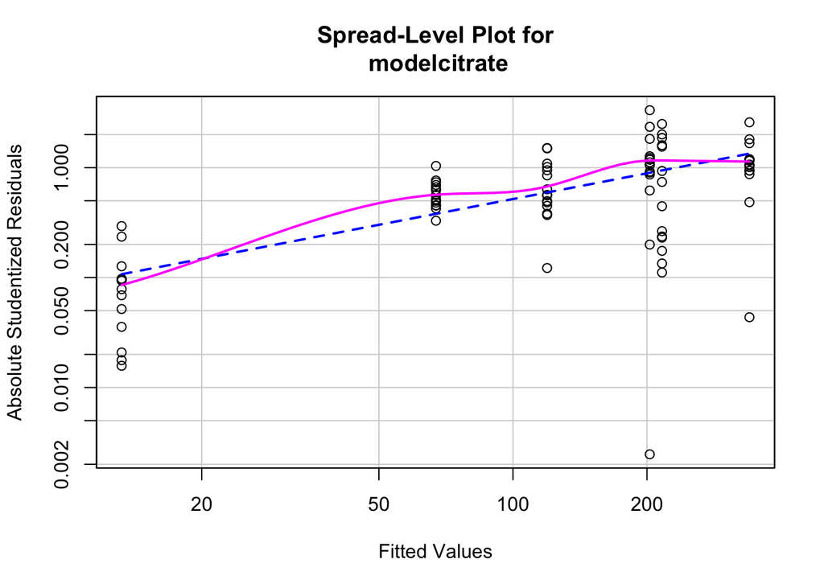

Figure 7: Spread-level plot of studentized residuals from the model

```
##
## Suggested power transformation:  0.2218539
```

```r
spreadLevelPlot(modelcitrate )
```

```r
ncvTest(modelcitrate)
```

```
## Non-constant Variance Score Test
## Variance formula: ~ fitted.values
## Chisquare = 15.38932, Df = 1, p = 8.7481e-05
```

It looks to me as if the residuals are still somewhat dependent on the citrate concentrations. Perhaps the model does not explain the treatments well enough.

# Linear mixed effect models

- Build beyond optimal model, meaning a model with all possible explanatory variables and as many interactions as possible
- Use AIC or BIC with REML estimation to compare models with the same fixed but different random structures and to derive the best random structure (smallest AIC or BIC value)
- Use t or F statistic with REML estimation to find the best fixed structure, except you have a model with nested fixed effects, then apply the ML estimation
- I used the Kenward_Roger approximations as recommended by Halekoh and Höjsgaard, 2014, implemented by Anova test = “F” in the car pck
- Present the results of the final model with REML estimation

Reference:

- Zuur, A. F. leno, E. N, Walker, NJ, Saveliev, AA & Smith, G M. 2009: Mixed effects models and extensions in ecology with R.
- https://www.westernsydney.edu.au/__data/assets/pdf_file/0004/947740/Rmanual_mixedeffects_20160914.pdf
- http://www.bodowinter.com/tutorial/bw_LME_tutorial2.pdf

```r
library(lme4)
library(lmerTest)
library(car)
library(rafalib)
library(visreg)
library(sjPlot)
library(sciplot)
library(nlme)
library(MASS)
library(ggpubr)
theme_set(theme_bw())
```

### Data overview

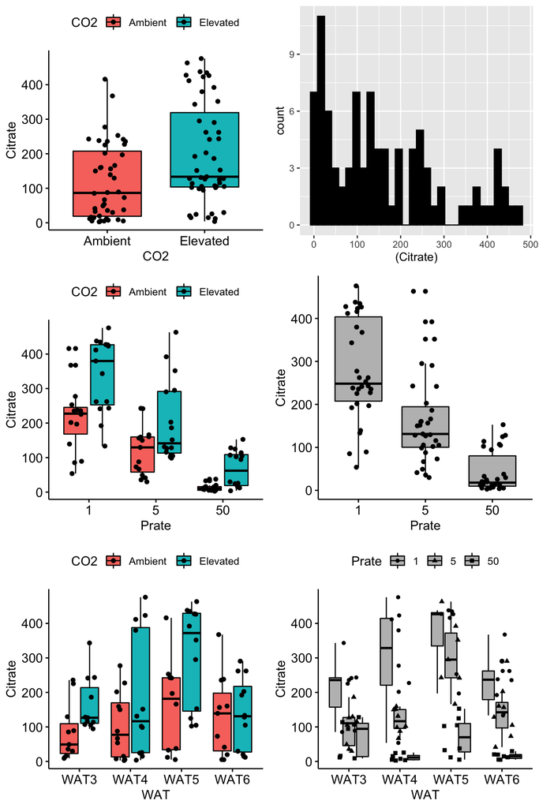

```r
p1.1 <- ggboxplot(data, y = "Citrate", x = "CO2", add = c("jitter"), fill = "CO2")
p1.2 <- ggplot(data, aes(x=(Citrate))) +  geom_histogram(color="black", fill="black")
p2.1 <- ggboxplot(data, y = "Citrate", x = "Prate", add = c("jitter"), fill = "CO2")
p2.2 <- ggboxplot(data, y = "Citrate", x = "Prate", add = c("jitter"), fill = "gray")
p3.1  <- ggboxplot(data, y = "Citrate", x = "WAT", add = c("jitter"), fill = "CO2")
p3.2 <- ggboxplot(data, y = "Citrate", x = "WAT", add = c("jitter"), fill = "gray", shape = "Prate")

ggarrange(p1.1, p1.2, p2.1, p2.2, p3.1, p3.2, nrow = 3, ncol = 2)
```

```r
shapiro.test(data$Citrate)
```

```
##
##  Shapiro-Wilk normality test
##
## data:  data$Citrate
## W = 0.90342, p-value = 5.199e-06
```

### Data overview - Square root transformed

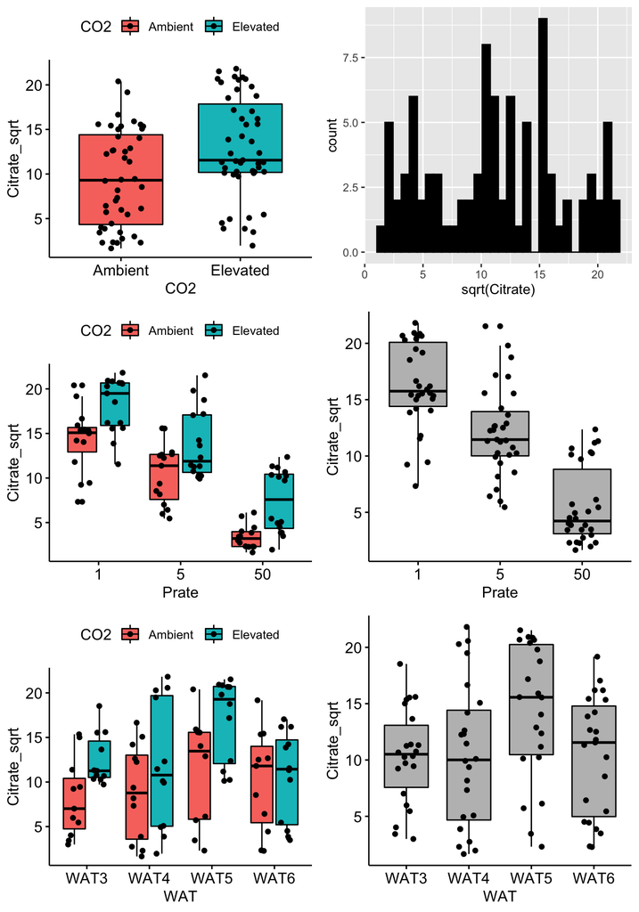

```r
data$Citrate_sqrt <- sqrt(data$Citrate)
# A quick overview of data
p1.1 <- ggboxplot(data, y = "Citrate_sqrt", x = "CO2", add = c("jitter"), fill = "CO2")
p1.2 <- ggplot(data, aes(x=sqrt(Citrate))) +  geom_histogram(color="black", fill="black")
p2.1 <- ggboxplot(data, y = "Citrate_sqrt", x = "Prate", add = c("jitter"), fill = "CO2")
p2.2 <- ggboxplot(data, y = "Citrate_sqrt", x = "Prate", add = c("jitter"), fill = "gray")
p3.1  <- ggboxplot(data, y = "Citrate_sqrt", x = "WAT", add = c("jitter"), fill = "CO2")
p3.2 <- ggboxplot(data, y = "Citrate_sqrt", x = "WAT", add = c("jitter"), fill = "gray")

ggarrange(p1.1, p1.2, p2.1, p2.2, p3.1, p3.2, nrow = 3, ncol = 2)
```

```r
shapiro.test(sqrt(data$Citrate))
```

```
##
##  Shapiro-Wilk normality test
##
## data:  sqrt(data$Citrate)
## W = 0.95753, p-value = 0.004718
```

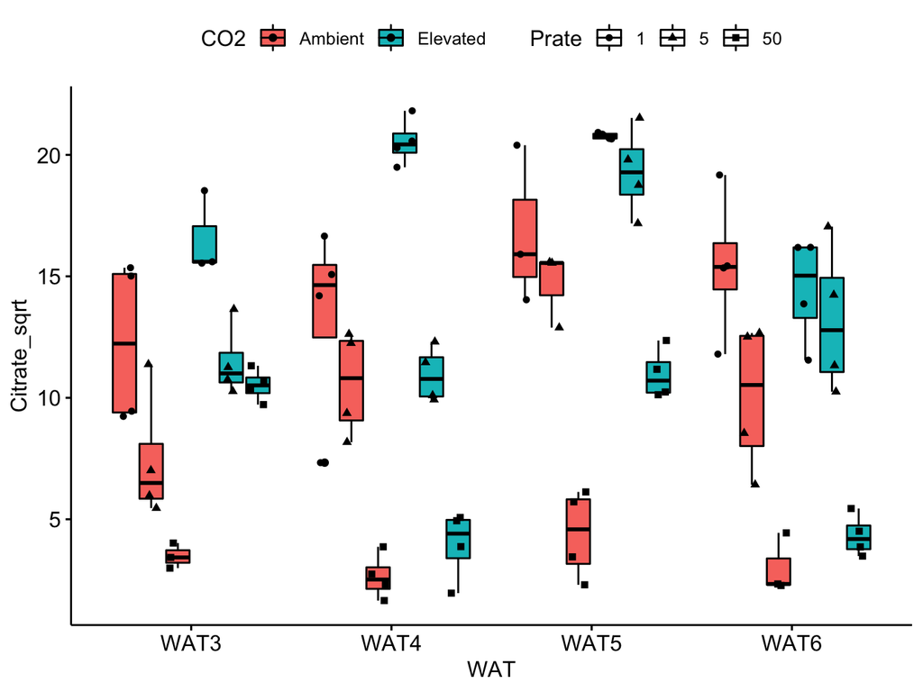

```r
ggboxplot(data, y = "Citrate_sqrt", x = "WAT", add = c("jitter"), fill = "CO2", shape = "Prate")
```

### Checking which random structure is most suitable

```r
M <- gls(sqrt(Citrate) ~ CO2 + Prate + CO2:Prate, data = na.omit(data))
M0 <- lme(sqrt(Citrate)  ~  CO2 + Prate + CO2:Prate  , random =~ 1 | WAT, data = na.omit(data))
M1 <- lme(sqrt(Citrate)  ~  CO2 + Prate + CO2:Prate  , random =~ 1 | WAT/Rep, data = na.omit(data))
M2 <- lme(sqrt(Citrate)  ~  CO2 + Prate + CO2:Prate  , random =~ 1 | Rep, data = na.omit(data))
anova(M, M0, M1, M2)
```

```
##    Model df      AIC      BIC    logLik   Test L.Ratio p-value
## M      1  7 473.0433 490.1419 -229.5217
## M0     2  8 451.3467 470.8879 -217.6734 1 vs 2 23.6966  <.0001
## M1     3  9 453.3467 475.3306 -217.6734 2 vs 3  0.0000  0.9998
## M2     4  8 475.0433 494.5845 -229.5217 3 vs 4 23.6966  <.0001
```

Looks like as if the using WAT (M0) as a random factor improves the model

### Next, initial diagnostics of this model

```r
data.naomit <- na.omit(data)

E <- resid(M0, type = 'normalized')
shapiro.test(E)
```

```
##
##  Shapiro-Wilk normality test
##
## data:  E
## W = 0.99035, p-value = 0.75
```

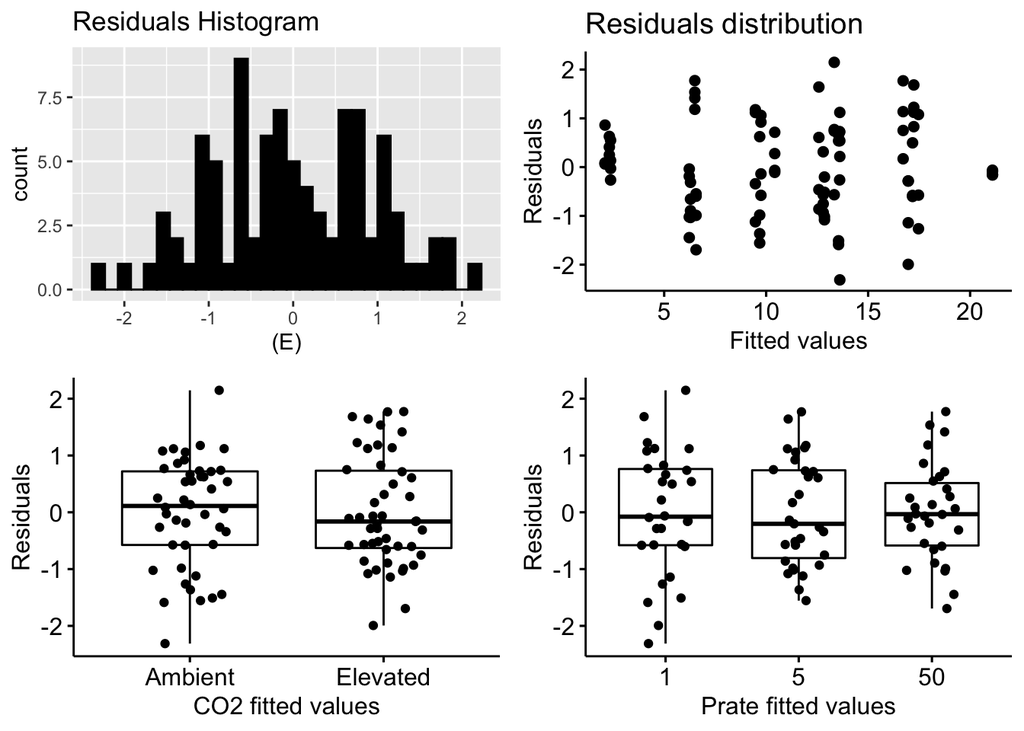

```r
E <- data.frame(E = E)
Ehist <- ggplot(E, aes(x=(E))) +  geom_histogram(color="black", fill="black") + ggtitle("Residuals Histogram")

F0 <- fitted(M0)
df <- data.frame(F0 = F0, E = E, CO2 = data.naomit$CO2, Prate = data.naomit$Prate)

residscatter <- ggscatter(data= df, x = "F0", y = "E", xlab = "Fitted values", ylab = "Residuals") + ggtitle("Residuals distribution")

CO2scatter <- ggboxplot(data= df, x = "CO2", y = "E", xlab = "CO2 fitted values", ylab = "Residuals", add = ("jitter"))

Pratescatter <- ggboxplot(data= df, x = "Prate", y = "E", xlab = "Prate fitted values", ylab = "Residuals", add = ("jitter"))

ggarrange(Ehist, residscatter, CO2scatter, Pratescatter, nrow = 2, ncol = 2)
```

Looks pretty good.

### Looking as model summary

```r
summary(M0)
```

```
## Linear mixed-effects model fit by REML
##  Data: na.omit(data)
##        AIC      BIC    logLik
##   451.3467 470.8879 -217.6734
##
## Random effects:
##  Formula: ~1 | WAT
##         (Intercept) Residual
## StdDev:    2.062725 2.716474
##
## Fixed effects: sqrt(Citrate) ~ CO2 + Prate + CO2:Prate
##                          Value Std.Error DF    t-value p-value
## (Intercept)          14.491934 1.2476733 82  11.615167  0.0000
## CO2Elevated           3.627935 0.9933161 82   3.652347  0.0005
## Prate5               -3.866780 0.9919160 82  -3.898294  0.0002
## Prate50             -11.239170 1.0114947 82 -11.111447  0.0000
## CO2Elevated:Prate5   -0.513974 1.3921485 82  -0.369195  0.7129
## CO2Elevated:Prate50   0.563208 1.4069456 82   0.400305  0.6900
##  Correlation:
##                     (Intr) CO2Elv Prate5 Prat50 CO2El:P5
## CO2Elevated         -0.398
## Prate5              -0.398  0.499
## Prate50             -0.391  0.492  0.490
## CO2Elevated:Prate5   0.283 -0.713 -0.713 -0.350
## CO2Elevated:Prate50  0.281 -0.707 -0.353 -0.720  0.503
##
## Standardized Within-Group Residuals:
##         Min          Q1         Med          Q3         Max
## -2.31204535 -0.59972355 -0.06680139  0.72318332  2.14757433
##
## Number of Observations: 91
## Number of Groups: 4
```